# AppFigures Data Challenge

## Jupyter Notebook

### AppFigures data challenge

#### Submitted by : Dhiraj Tripathi , Master's of IT & Analytics, Rutgers University - NJ

#### email: dhiraj.tripathi@rutgers.edu , contact : - 551-358-9117

### Problem Statement:

In this data challenge, we are given two different datasets as 'ranks.csv' and 'sales.csv' . Our primary goal is to analyze the tend between the ranks and sales. The thought process here is to estimate sales of an application by considering ranks as a function. We will feed in some data to our machine learning model and forecast the sales value 3 months ahead.

To achieve this, we will start by importing some required packages for our script as below:

```python
import pandas as pd
```

### Reading the Csv:

Let's read the two csv files given to us and have a quick look at the dimensions and data types of the columns from these files.

```python
import numpy as np

rankdata = pd.read_csv("F:/GIT/Appfigues/ranks.csv" , index_col = False)
salesdata = pd.read_csv("F:/GIT/Appfigues/sales.csv", index_col = False)
```

```python
rankdata.head()
```

|  | Date | app_id | r0 | r1 | r2 | r3 | r4 | r5 | r6 | r7 | ... | s1 | s2 | s3 | s4 | s5 | cs1 | cs2 | cs3 | cs4 | cs5 |
| --- | --- | --- | --- | --- | --- | --- | --- | --- | --- | --- | --- | --- | --- | --- | --- | --- | --- | --- | --- | --- | --- |
| 0 | 2016-01-01 | 1 | 622.0 | 622.0 | 621.0 | 619.0 | 621.0 | 561.0 | 562.0 | 563.0 | ... | 0.0 | 0.0 | 0.0 | 0.0 | 0.0 | 47.0 | 8.0 | 6.0 | 12.0 | 30.0 |
| 1 | 2016-01-01 | 2 | 574.0 | 574.0 | 573.0 | 571.0 | 573.0 | 543.0 | 544.0 | 545.0 | ... | 0.0 | 0.0 | 0.0 | 0.0 | 0.0 | 142.0 | 88.0 | 296.0 | 826.0 | 3177.0 |
| 2 | 2016-01-01 | 4 | 144.0 | 144.0 | 144.0 | 144.0 | 144.0 | 144.0 | 143.0 | 142.0 | ... | 0.0 | 0.0 | 0.0 | 2.0 | 4.0 | 552.0 | 321.0 | 705.0 | 1409.0 | 4417.0 |
| 3 | 2016-01-01 | 5 | 919.0 | 919.0 | 918.0 | 914.0 | 917.0 | 875.0 | 874.0 | 877.0 | ... | 0.0 | 0.0 | 0.0 | 0.0 | 0.0 | 226.0 | 95.0 | 322.0 | 1121.0 | 4013.0 |
| 4 | 2016-01-01 | 8 | 903.0 | 903.0 | 902.0 | 898.0 | 901.0 | 920.0 | 919.0 | 922.0 | ... | 0.0 | 0.0 | 0.0 | 0.0 | 2.0 | 356.0 | 181.0 | 362.0 | 1744.0 | 6884.0 |

5 rows × 36 columns

```python
salesdata.head()
```

|  | Date | app_id | sales |
| --- | --- | --- | --- |
| 0 | 2016-01-01 | 320 | 2412 |
| 1 | 2016-01-01 | 406 | 1308 |
| 2 | 2016-01-01 | 459 | 2037 |
| 3 | 2016-01-01 | 722 | 2052 |
| 4 | 2016-01-01 | 1234 | 1553 |

```python
rankdata.ndim
```

```
2
```

```python
rankdata.info()
```

```
<class 'pandas.core.frame.DataFrame'>
RangeIndex: 97608 entries, 0 to 97607
Data columns (total 36 columns):
Date      97608 non-null object
app_id    97608 non-null int64
r0        89992 non-null float64
r1        89953 non-null float64
r2        88974 non-null float64
r3        89999 non-null float64
r4        89997 non-null float64
r5        89886 non-null float64
r6        89888 non-null float64
r7        89991 non-null float64
r8        89994 non-null float64
r9        89995 non-null float64
r10       89977 non-null float64
r11       89997 non-null float64
r12       89958 non-null float64
r13       89931 non-null float64
r14       89990 non-null float64
r15       89998 non-null float64
r16       89960 non-null float64
r17       89984 non-null float64
r18       89991 non-null float64
r19       89973 non-null float64
r20       89993 non-null float64
r21       89999 non-null float64
r22       89995 non-null float64
r23       89981 non-null float64
s1        93967 non-null float64
s2        93967 non-null float64
s3        93967 non-null float64
s4        93967 non-null float64
s5        93967 non-null float64
cs1       93967 non-null float64
cs2       93967 non-null float64
cs3       93967 non-null float64
cs4       93967 non-null float64
cs5       93967 non-null float64
dtypes: float64(34), int64(1), object(1)
memory usage: 26.8+ MB
```

```python
rankdata.shape
```

```
(97608, 36)
```

```python
salesdata.info()
```

```
<class 'pandas.core.frame.DataFrame'>
RangeIndex: 1105 entries, 0 to 1104
Data columns (total 3 columns):
Date      1105 non-null object
app_id    1105 non-null int64
sales     1105 non-null int64
dtypes: int64(2), object(1)
memory usage: 26.0+ KB
```

```python
salesdata.shape
```

```
(1105, 3)
```

We can notice that our data sets are sufficiently large in terms of number of rows * columns and also there are some matching columns in both the datasets such as Date , app_id .

### Data Munging:

The first step towards creating a model is to merge both the datasets and extract only the relevant information from both. For this, we will use the merge function in python as if we are using an inner join in sql.

```python
subsetDataFrame = pd.merge(rankdata, salesdata, how='inner', on=['Date', 'app_id'])
```

```python
print(subsetDataFrame)
```

```
            Date  app_id     r0     r1     r2     r3     r4     r5     r6  \
0     2016-01-01     320  488.0  488.0  488.0  486.0  487.0  475.0  476.0
1     2016-01-01     406  685.0  685.0  684.0  681.0  684.0  702.0  701.0
2     2016-01-01     459  597.0  597.0  596.0  594.0  596.0  603.0  604.0
3     2016-01-01     722  532.0  532.0  532.0  530.0  531.0  547.0  548.0
4     2016-01-01    1234  813.0  813.0  812.0  809.0  812.0  831.0  830.0
5     2016-01-01    1490  528.0  528.0  528.0  526.0  527.0  519.0  520.0
6     2016-01-01    2398    NaN    NaN    NaN    NaN    NaN    NaN    NaN
7     2016-01-01    2891    5.0    5.0    5.0    5.0    5.0    5.0    6.0
8     2016-01-02     320  438.0  435.0  446.0  445.0  446.0  444.0  446.0
9     2016-01-02     406  738.0  735.0  747.0  748.0  749.0  746.0  749.0
10    2016-01-02     459  610.0  607.0  582.0  581.0  582.0  580.0  582.0
11    2016-01-02     722  601.0  598.0  603.0  603.0  604.0  602.0  604.0
12    2016-01-02    1234  678.0  675.0  698.0  698.0  699.0  696.0  699.0
13    2016-01-02    1490  535.0  532.0  564.0  563.0  564.0  562.0  564.0
```

[output cut: 175 more lines]

### Data cleaning:

As we can see in the above dataframe , there are a lot of NaN values , which can distract our ML model. For the sake of simplicity , we will drop the records which have missing values in it. We can also impute the missing values, if required. But, our dataframe is large enough to train the model, even if we drop the records.

```python
subsetDataFrame.dropna(inplace=True)
```

```python
subsetDataFrame.shape
```

```
(919, 37)
```

```python
pd.set_option('display.max_columns', None)
pd.set_option('display.max_rows', 20)
```

```python
display(subsetDataFrame)
```

|  | Date | app_id | r0 | r1 | r2 | r3 | r4 | r5 | r6 | r7 | r8 | r9 | r10 | r11 | r12 | r13 | r14 | r15 | r16 | r17 | r18 | r19 | r20 | r21 | r22 | r23 | s1 | s2 | s3 | … |
| --- | --- | --- | --- | --- | --- | --- | --- | --- | --- | --- | --- | --- | --- | --- | --- | --- | --- | --- | --- | --- | --- | --- | --- | --- | --- | --- | --- | --- | --- | --- |
| 0 | 2016-01-01 | 320 | 488.0 | 488.0 | 488.0 | 486.0 | 487.0 | 475.0 | 476.0 | 477.0 | 478.0 | 477.0 | 478.0 | 478.0 | 478.0 | 472.0 | 472.0 | 472.0 | 472.0 | 452.0 | 452.0 | 452.0 | 452.0 | 452.0 | 452.0 | 438.0 | 1.0 | 0.0 | 2.0 | … |
| 1 | 2016-01-01 | 406 | 685.0 | 685.0 | 684.0 | 681.0 | 684.0 | 702.0 | 701.0 | 704.0 | 705.0 | 703.0 | 717.0 | 717.0 | 717.0 | 738.0 | 738.0 | 738.0 | 738.0 | 742.0 | 742.0 | 742.0 | 742.0 | 741.0 | 742.0 | 738.0 | 0.0 | 0.0 | 0.0 | … |
| 2 | 2016-01-01 | 459 | 597.0 | 597.0 | 596.0 | 594.0 | 596.0 | 603.0 | 604.0 | 605.0 | 606.0 | 604.0 | 618.0 | 618.0 | 618.0 | 607.0 | 607.0 | 607.0 | 607.0 | 598.0 | 598.0 | 598.0 | 598.0 | 598.0 | 598.0 | 610.0 | 0.0 | 0.0 | 0.0 | … |
| 3 | 2016-01-01 | 722 | 532.0 | 532.0 | 532.0 | 530.0 | 531.0 | 547.0 | 548.0 | 549.0 | 550.0 | 548.0 | 574.0 | 574.0 | 574.0 | 577.0 | 577.0 | 577.0 | 577.0 | 594.0 | 594.0 | 594.0 | 594.0 | 594.0 | 594.0 | 601.0 | 1.0 | 0.0 | 2.0 | … |
| 4 | 2016-01-01 | 1234 | 813.0 | 813.0 | 812.0 | 809.0 | 812.0 | 831.0 | 830.0 | 833.0 | 834.0 | 832.0 | 802.0 | 802.0 | 802.0 | 775.0 | 775.0 | 775.0 | 775.0 | 713.0 | 713.0 | 713.0 | 713.0 | 712.0 | 713.0 | 678.0 | 0.0 | 0.0 | 0.0 | … |
| 5 | 2016-01-01 | 1490 | 528.0 | 528.0 | 528.0 | 526.0 | 527.0 | 519.0 | 520.0 | 521.0 | 522.0 | 520.0 | 506.0 | 506.0 | 506.0 | 506.0 | 506.0 | 506.0 | 506.0 | 522.0 | 522.0 | 522.0 | 522.0 | 522.0 | 522.0 | 535.0 | 2.0 | 0.0 | 0.0 | … |
| 7 | 2016-01-01 | 2891 | 5.0 | 5.0 | 5.0 | 5.0 | 5.0 | 5.0 | 6.0 | 6.0 | 6.0 | 6.0 | 6.0 | 6.0 | 6.0 | 6.0 | 6.0 | 6.0 | 6.0 | 6.0 | 6.0 | 6.0 | 6.0 | 6.0 | 6.0 | 6.0 | 8.0 | 4.0 | 8.0 | … |
| 8 | 2016-01-02 | 320 | 438.0 | 435.0 | 446.0 | 445.0 | 446.0 | 444.0 | 446.0 | 446.0 | 453.0 | 453.0 | 452.0 | 455.0 | 455.0 | 454.0 | 470.0 | 470.0 | 484.0 | 484.0 | 484.0 | 484.0 | 492.0 | 493.0 | 490.0 | 492.0 | 0.0 | 0.0 | 0.0 | … |
| 9 | 2016-01-02 | 406 | 738.0 | 735.0 | 747.0 | 748.0 | 749.0 | 746.0 | 749.0 | 749.0 | 761.0 | 761.0 | 760.0 | 766.0 | 766.0 | 765.0 | 779.0 | 780.0 | 754.0 | 756.0 | 756.0 | 756.0 | 745.0 | 746.0 | 743.0 | 740.0 | 0.0 | 0.0 | 0.0 | … |
| 10 | 2016-01-02 | 459 | 610.0 | 607.0 | 582.0 | 581.0 | 582.0 | 580.0 | 582.0 | 582.0 | 584.0 | 584.0 | 583.0 | 593.0 | 593.0 | 592.0 | 587.0 | 587.0 | 604.0 | 604.0 | 604.0 | 604.0 | 571.0 | 571.0 | 568.0 | 558.0 | 1.0 | 0.0 | 0.0 | … |
| ... | ... | ... | ... | ... | ... | ... | ... | ... | ... | ... | ... | ... | ... | ... | ... | ... | ... | ... | ... | ... | ... | ... | ... | ... | ... | ... | ... | ... | ... | … |
| 1093 | 2016-03-31 | 1264 | 989.0 | 977.0 | 977.0 | 977.0 | 977.0 | 977.0 | 977.0 | 947.0 | 947.0 | 947.0 | 947.0 | 947.0 | 947.0 | 947.0 | 947.0 | 947.0 | 947.0 | 947.0 | 947.0 | 947.0 | 947.0 | 947.0 | 947.0 | 947.0 | 1.0 | 0.0 | 1.0 | … |
| 1094 | 2016-03-31 | 1461 | 882.0 | 884.0 | 884.0 | 884.0 | 884.0 | 884.0 | 884.0 | 913.0 | 913.0 | 913.0 | 913.0 | 913.0 | 913.0 | 913.0 | 913.0 | 913.0 | 913.0 | 913.0 | 913.0 | 913.0 | 913.0 | 913.0 | 913.0 | 913.0 | 0.0 | 0.0 | 0.0 | … |
| 1095 | 2016-03-31 | 1490 | 547.0 | 587.0 | 587.0 | 587.0 | 587.0 | 587.0 | 587.0 | 639.0 | 639.0 | 639.0 | 639.0 | 639.0 | 639.0 | 639.0 | 639.0 | 639.0 | 639.0 | 639.0 | 639.0 | 639.0 | 639.0 | 639.0 | 639.0 | 639.0 | 2.0 | 0.0 | 0.0 | … |
| 1096 | 2016-03-31 | 1874 | 545.0 | 571.0 | 571.0 | 571.0 | 571.0 | 571.0 | 571.0 | 583.0 | 583.0 | 583.0 | 583.0 | 583.0 | 583.0 | 583.0 | 583.0 | 583.0 | 583.0 | 583.0 | 583.0 | 583.0 | 583.0 | 583.0 | 583.0 | 583.0 | 0.0 | 0.0 | 0.0 | … |
| 1097 | 2016-03-31 | 2346 | 362.0 | 377.0 | 377.0 | 377.0 | 377.0 | 377.0 | 377.0 | 394.0 | 394.0 | 394.0 | 394.0 | 394.0 | 394.0 | 394.0 | 394.0 | 394.0 | 394.0 | 394.0 | 394.0 | 394.0 | 394.0 | 394.0 | 394.0 | 394.0 | 2.0 | 3.0 | 3.0 | … |
| 1098 | 2016-03-31 | 2398 | 935.0 | 916.0 | 916.0 | 916.0 | 916.0 | 916.0 | 916.0 | 919.0 | 919.0 | 919.0 | 919.0 | 919.0 | 919.0 | 919.0 | 919.0 | 919.0 | 919.0 | 919.0 | 919.0 | 919.0 | 919.0 | 919.0 | 919.0 | 919.0 | 0.0 | 0.0 | 0.0 | … |
| 1099 | 2016-03-31 | 2667 | 475.0 | 488.0 | 488.0 | 488.0 | 488.0 | 488.0 | 488.0 | 476.0 | 476.0 | 476.0 | 476.0 | 476.0 | 476.0 | 476.0 | 476.0 | 476.0 | 476.0 | 476.0 | 476.0 | 476.0 | 476.0 | 476.0 | 476.0 | 476.0 | 1.0 | 1.0 | 0.0 | … |
| 1100 | 2016-03-31 | 2891 | 20.0 | 21.0 | 21.0 | 21.0 | 21.0 | 21.0 | 21.0 | 22.0 | 22.0 | 22.0 | 22.0 | 22.0 | 22.0 | 22.0 | 22.0 | 22.0 | 22.0 | 22.0 | 22.0 | 22.0 | 22.0 | 22.0 | 22.0 | 22.0 | 3.0 | 1.0 | 2.0 | … |
| 1101 | 2016-03-31 | 3308 | 964.0 | 904.0 | 904.0 | 904.0 | 904.0 | 904.0 | 904.0 | 959.0 | 959.0 | 959.0 | 959.0 | 959.0 | 959.0 | 959.0 | 959.0 | 959.0 | 959.0 | 959.0 | 959.0 | 959.0 | 959.0 | 959.0 | 959.0 | 959.0 | 0.0 | 0.0 | 0.0 | … |
| 1102 | 2016-03-31 | 3373 | 282.0 | 310.0 | 310.0 | 310.0 | 310.0 | 310.0 | 310.0 | 314.0 | 314.0 | 314.0 | 314.0 | 314.0 | 314.0 | 314.0 | 314.0 | 314.0 | 314.0 | 314.0 | 314.0 | 314.0 | 314.0 | 314.0 | 314.0 | 314.0 | 0.0 | 1.0 | 0.0 | … |

### Data Aggregation:

As we can see in the above dataframe, we have an hourly ranking of applications on a daily basis. An important thing to note is that these ranks are deviating within a given short range of values. In such cases, we can also take the average value of all the ranks and ratings to simplify our problem and then create a single column for both the properties.

```python
subsetDataFrame['avgrank'] = subsetDataFrame.iloc[:,3:26].mean(axis=1)
subsetDataFrame['avgrating'] = subsetDataFrame.iloc[:,27:31].mean(axis=1)
```

```python
newData = subsetDataFrame[['Date','app_id','sales','avgrank','avgrating']]
```

### Data Extraction:

We will now only consider the average rank & rating columns instead of hourly rank columns. For this, we subsetted the data and extracted only the relevant columns in a new data frame.

```python
print(newData)
```

```
            Date  app_id  sales     avgrank  avgrating
0     2016-01-01     320   2412  469.739130       0.50
1     2016-01-01     406   1308  719.173913       0.00
2     2016-01-01     459   2037  603.695652       0.25
3     2016-01-01     722   2052  567.913043       2.75
4     2016-01-01    1234   1553  776.826087       0.00
5     2016-01-01    1490   2152  518.260870       0.50
7     2016-01-01    2891  89289    5.782609      33.50
8     2016-01-02     320   1622  464.043478       0.00
9     2016-01-02     406   1110  754.652174       0.00
10    2016-01-02     459   1553  586.217391       0.25
11    2016-01-02     722   1467  617.782609       1.00
12    2016-01-02    1234   1011  727.695652       0.00
13    2016-01-02    1490   1722  546.260870       0.50
16    2016-01-02    2891  84915    5.826087      35.25
```

[output cut: 905 more lines]

```python
newData.avgrating.dtype
```

```
dtype('float64')
```

Further we noticed that avg rating column has a lot of values set as 0.00 . We can always replace these null values by a normalize function or we can also replace them by mean. But, replcaing them by either of them in this case, will bias the ML model. We want our model to be trained in such a way, that it can interpret that low ranks have higher sales. For the ease of use, we will only consider avg rank as a factor influencing the sales.

```python
newData1 = newData[['Date','sales','avgrank']]
print(newData1)
```

```
            Date  sales     avgrank
0     2016-01-01   2412  469.739130
1     2016-01-01   1308  719.173913
2     2016-01-01   2037  603.695652
3     2016-01-01   2052  567.913043
4     2016-01-01   1553  776.826087
5     2016-01-01   2152  518.260870
7     2016-01-01  89289    5.782609
8     2016-01-02   1622  464.043478
9     2016-01-02   1110  754.652174
10    2016-01-02   1553  586.217391
11    2016-01-02   1467  617.782609
12    2016-01-02   1011  727.695652
13    2016-01-02   1722  546.260870
16    2016-01-02  84915    5.826087
```

[output cut: 905 more lines]

```python
newData1.columns
```

```
Index(['Date', 'sales', 'avgrank'], dtype='object')
```

```python
newData1.Date.dtype
```

```
dtype('O')
```

```python
pd.options.mode.chained_assignment = None  # default='warn'
```

### Data Formatting:

As we can see that there is a date column in our dataframe but it is of type 'O' . So we will convert the data type and date & time format so that it can be interpreted as a time series data by our model. We will also change the index of the dataframe to Date.

```python
newData1['Date'] = pd.to_datetime(newData1['Date'] , format = '%Y/%m/%d')
newData2 = newData1.drop(['Date'], axis=1)
newData2.index = newData.Date
```

```python
print(newData2)
```

```
            sales     avgrank
Date
2016-01-01   2412  469.739130
2016-01-01   1308  719.173913
2016-01-01   2037  603.695652
2016-01-01   2052  567.913043
2016-01-01   1553  776.826087
2016-01-01   2152  518.260870
2016-01-01  89289    5.782609
2016-01-02   1622  464.043478
2016-01-02   1110  754.652174
2016-01-02   1553  586.217391
2016-01-02   1467  617.782609
2016-01-02   1011  727.695652
2016-01-02   1722  546.260870
2016-01-02  84915    5.826087
2016-01-03   1564  508.695652
2016-01-03    963  762.434783
2016-01-03   1409  560.521739
2016-01-03   1371  676.000000
2016-01-03    938  829.217391
2016-01-03   1662  560.913043
2016-01-03   2029  680.086957
2016-01-03  61345    5.000000
2016-01-04   1609  525.695652
2016-01-04   1168  797.217391
2016-01-04   1732  573.826087
2016-01-04   1421  715.043478
2016-01-04    989  840.652174
2016-01-04   1081  573.782609
2016-01-04   1460  654.565217
2016-01-04  58943    6.391304
2016-01-05   1594  548.173913
2016-01-05   1163  750.869565
2016-01-05   1392  563.130435
2016-01-05   1482  757.086957
2016-01-05   1055  875.173913
2016-01-05    984  743.217391
2016-01-05   1102  807.869565
2016-01-05  62196   10.782609
```

[output cut: 866 more lines]

```
2016-03-31   2041  445.000000
2016-03-31   1526  506.130435
2016-03-31   1157  622.652174
2016-03-31   1388  673.521739
2016-03-31   1800  500.913043
2016-03-31   2433  954.826087
2016-03-31   1022  905.434783
2016-03-31   1223  625.434783
2016-03-31    237  579.869565
2016-03-31  11099  389.565217
2016-03-31   1372  918.217391
2016-03-31   3294  479.130435
2016-03-31  35903   21.739130
2016-03-31    777  944.652174
2016-03-31   3770  312.956522
```

### Training Data:

We will now extract the 80% values of this new dataframe and treat them as training data values.

```python
train = newData2[:int(0.8*(len(newData2)))]
```

```python
import matplotlib.pyplot as plt
```

Now let's plot the sales values so that it gives us an idea of how widely spread the sales values are. It gives us an insight on the range of values for sales.

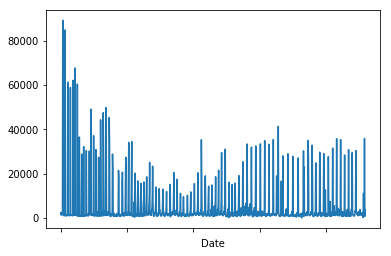

```python
newData2['sales'].plot()
```

### Check for Time Series Stationarity:

In time series analysis and forecasting, it is important for us to know if the time series in stationary or not. This can be done by plotting a graph and more precisely by running some statistical tests.

There are many tests which can tell you about the stationarity of the time series data, like ADF test, KPSS test etc. We have used an ADF (Dickey-Fuller) test to determine this.

```python
from statsmodels.tsa.stattools import adfuller
def adf_test(timeseries):
    #Perform Dickey-Fuller test:
    print ('Results of Dickey-Fuller Test:')
    dftest = adfuller(timeseries, autolag='AIC')
    dfoutput = pd.Series(dftest[0:4], index=['Test Statistic','p-value','#Lags Used','Number of Observations Used'])
    for key,value in dftest[4].items():
       dfoutput['Critical Value (%s)'%key] = value
    print (dfoutput)

#apply adf test on the series
adf_test(train['sales'])
```

```
Results of Dickey-Fuller Test:
Test Statistic                  -4.060158
p-value                          0.001126
#Lags Used                      18.000000
Number of Observations Used    716.000000
Critical Value (1%)             -3.439516
Critical Value (5%)             -2.865585
Critical Value (10%)            -2.568924
dtype: float64
```

### Note :

In this test, as the Test Statistic is less than the critical value, we can reject the null hypothesis, which also means that the series is stationary. If the test statistic was higher than the critical value, then we cannot reject the null hypothesis and the time series in that case will be non-stationary. Differencing is required to convert a non stationary time series into a stationary one.

### Vector Autoregression (VAR) Model:

It is important for us to understand which model to be used with respect to the problem statement. In our case, we should notice that the time series is not a univariate time series but a multivariate time series. In such time series, there are more than one variables to be fed in the model as input. As we know here, Sales is a function of Time and Ranks, so this problem cannot be solved using ARIMA model. Instead, we will use a Vector Autoregression Model and train it to understand that Sales is a function of Time and Rank.

```python
from statsmodels.tsa.vector_ar.var_model import VAR
model = VAR(endog=train)
results = model.fit()
```

```python
results.summary()
```

```
  Summary of Regression Results
==================================
Model:                         VAR
Method:                        OLS
Date:           Wed, 21, Nov, 2018
Time:                     05:58:08
--------------------------------------------------------------------
No. of Equations:         2.00000    BIC:                    28.9941
Nobs:                     734.000    HQIC:                   28.9710
Log likelihood:          -12704.0    FPE:                3.76394e+12
AIC:                      28.9565    Det(Omega_mle):     3.73336e+12
--------------------------------------------------------------------
Results for equation sales
=============================================================================
                coefficient       std. error           t-stat            prob
-----------------------------------------------------------------------------
const           7188.095553      1327.119449            5.416           0.000
L1.sales          -0.013136         0.050402           -0.261           0.794
L1.avgrank        -3.750460         1.978577           -1.896           0.058
=============================================================================

Results for equation avgrank
=============================================================================
                coefficient       std. error           t-stat            prob
-----------------------------------------------------------------------------
const            499.568193        33.416604           14.950           0.000
L1.sales          -0.002050         0.001269           -1.616           0.106
L1.avgrank         0.107571         0.049820            2.159           0.031
=============================================================================

Correlation matrix of residuals
              sales   avgrank
sales      1.000000 -0.681426
avgrank   -0.681426  1.000000
```

### Plot the model_fit object:

Lets have a look at the variance of the sales and ranks data. These plots are generated from the interpretation of the training data by VAR model.

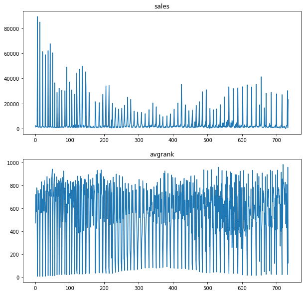

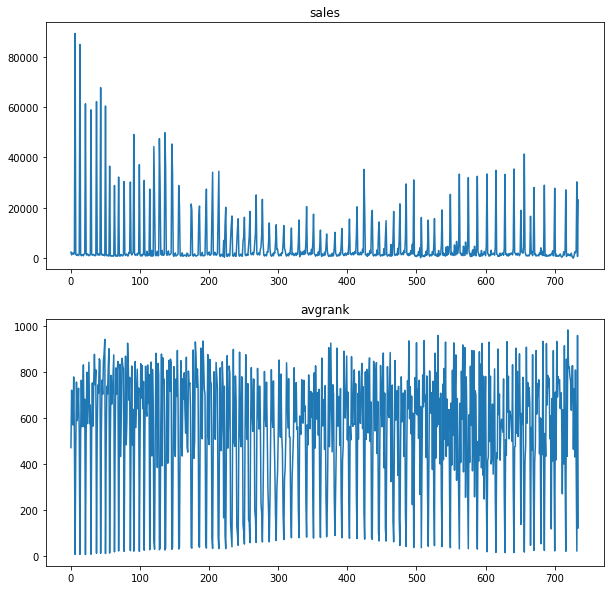

```python
results.plot()
```

Lets plot the auto-correlation function to understand the correlation for time series observations with respect to the previous time steps, called lags.

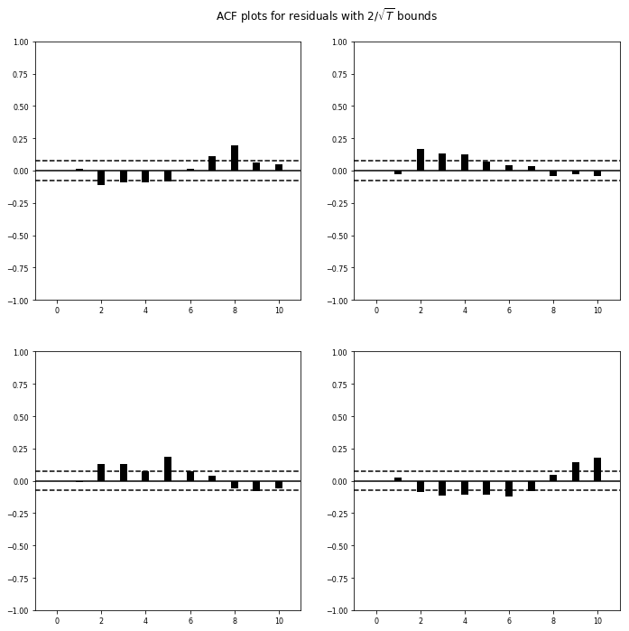

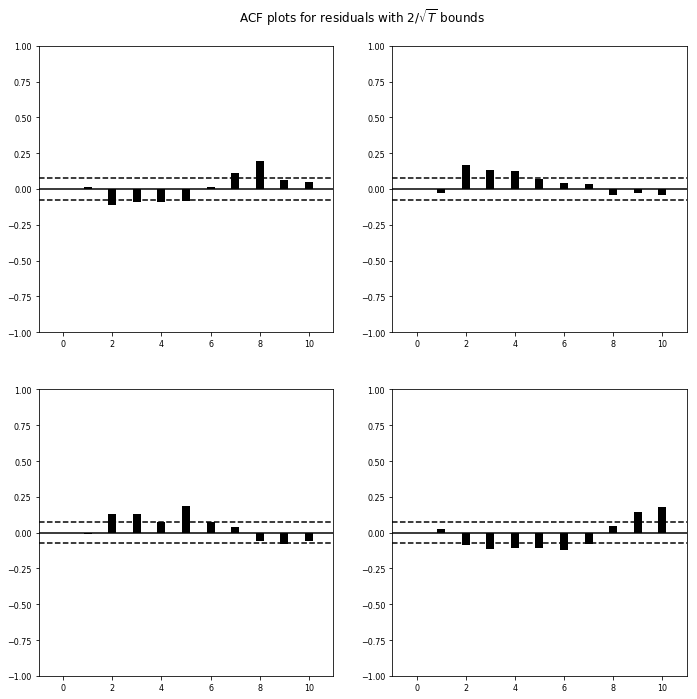

```python
results.plot_acorr()
```

```python
 results = model.fit(maxlags=15, ic='aic')
```

```python
lag_order = results.k_ar
```

### Fit the model:

```python
Estimates = results.forecast(newData2.values[-lag_order:], 90)
print(Estimates)
```

```
[[ 2840.9997398    766.55819819]
 [-3328.33224535   768.92426941]
 [ 3442.98895128   711.5326563 ]
 [ 6847.15397636   608.70795631]
 [11409.9897393    483.837487  ]
 [13394.93730923   464.58679922]
 [ 4279.04575772   540.87150138]
 [ 8296.26502653   464.07885361]
 [ 4054.8054321    605.09264174]
 [  231.85003493   696.99709723]
 [11334.16608751   465.13579213]
 [ 5403.44923458   672.80952569]
 [ 5432.91721041   586.72654792]
 [ 8019.8436417    592.6446544 ]
 [ 4546.70601552   567.03138658]
 [ 6033.86097957   565.91417052]
 [ 5403.18085084   553.77807264]
 [ 6431.92055022   525.28791605]
 [ 8427.96098473   522.71537805]
 [ 5305.53989777   567.49954485]
 [ 6536.30019512   570.64005632]
 [ 6193.72228193   573.12941588]
 [ 3804.96923387   633.59549812]
 [ 6048.63990018   570.52243336]
 [ 5762.96746691   575.97963205]
 [ 5780.71257099   556.68051503]
 [ 6849.01283309   542.48619231]
 [ 5855.8400033    537.36308196]
 [ 6305.73027813   544.80184995]
 [ 5722.99811567   558.13645455]
 [ 5368.1139812    568.10714192]
 [ 5982.92748944   571.36146014]
 [ 5302.00933452   577.14655284]
 [ 5565.58875399   579.0085594 ]
 [ 5889.43201279   558.93154261]
 [ 5391.16869031   566.01017793]
 [ 5725.38322837   553.05561002]
 [ 5787.20073179   547.37273024]
 [ 5683.40167542   549.25198014]
 [ 5871.70661985   551.5172317 ]
```

[output cut: 35 more lines]

```
 [ 5137.4719728    553.6347964 ]
 [ 5139.95256492   552.68124278]
 [ 5144.52145518   551.79885458]
 [ 5146.85829413   551.00722072]
 [ 5145.82042273   550.58393884]
 [ 5137.23587609   550.64909281]
 [ 5123.84952527   551.01838741]
 [ 5109.50839633   551.47860867]
 [ 5092.83408089   551.98765892]
 [ 5081.35985583   552.10870262]
 [ 5075.40449536   551.97897494]
 [ 5071.2599925    551.59387601]
 [ 5073.11083862   550.99538795]
 [ 5073.39811032   550.50581757]
 [ 5072.09376233   550.12526407]]
```

Lets plot the forecasted values against the Observed value and Std. error.

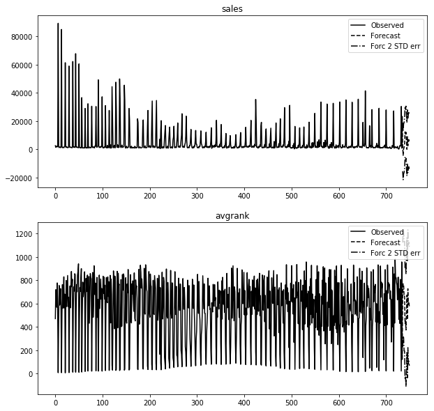

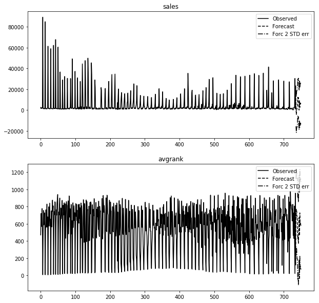

```python
results.plot_forecast(15)
```

## Final Data:

We have set our start date to 2016-04-01 and forecasted the values for three months for two variables i.e., ranks and sales. We also appended the app id colum from the previous dataframes and the final data looks like below.

```python
dataset = pd.DataFrame({'sales_est':Estimates[:,0],'ranks_est':Estimates[:,1]})
date = np.array('2016-04-01', dtype=np.datetime64)
Futuredate = date + np.arange(90)
df = pd.DataFrame(data =Futuredate,columns=['Dates'])
df['app_id'] = salesdata['app_id'].astype(int)
df['sales_est'] = dataset['sales_est'].astype(int)
df['ranks_est'] = dataset['ranks_est'].astype(int)
print(df)
```

```
        Dates  app_id  sales_est  ranks_est
0  2016-04-01     320       2840        766
1  2016-04-02     406      -3328        768
2  2016-04-03     459       3442        711
3  2016-04-04     722       6847        608
4  2016-04-05    1234      11409        483
5  2016-04-06    1490      13394        464
6  2016-04-07    2398       4279        540
7  2016-04-08    2891       8296        464
8  2016-04-09     320       4054        605
9  2016-04-10     406        231        696
..        ...     ...        ...        ...
80 2016-06-20    2891       5137        550
81 2016-06-21     320       5123        551
82 2016-06-22     406       5109        551
83 2016-06-23     459       5092        551
84 2016-06-24     722       5081        552
85 2016-06-25     907       5075        551
86 2016-06-26    1234       5071        551
87 2016-06-27    1490       5073        550
88 2016-06-28    2346       5073        550
89 2016-06-29    2398       5072        550

[90 rows x 4 columns]
```

### Save_to_CSV:

As required in the problem statement, we are required to save the data in csv format containing the above columns. to_csv function will save the dataframe in the correct working directory.

```python
df.to_dense().to_csv("estimates.csv", index = False, sep=',', encoding='utf-8')
```

Let's find the top 10 app_id by sales by running a simple command as below:

```python
df1 = df.nlargest(10, 'sales_est', keep='first')
print(df1)
```

```
        Dates  app_id  sales_est  ranks_est
5  2016-04-06    1490      13394        464
4  2016-04-05    1234      11409        483
10 2016-04-11     459      11334        465
18 2016-04-19     406       8427        522
7  2016-04-08    2891       8296        464
13 2016-04-14    1490       8019        592
26 2016-04-27     406       6849        542
3  2016-04-04     722       6847        608
20 2016-04-21     722       6536        570
17 2016-04-18     320       6431        525
```

We can visualize the app_id by total sales and take a quick look as to which app_id exhibited the most sales as per our forecast.

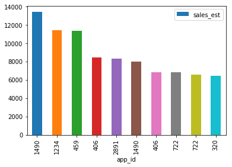

```python
df1.plot(x = 'app_id' , y = 'sales_est',kind = 'bar')
```

We can also visualize top 10 ranks in terms of total sales.

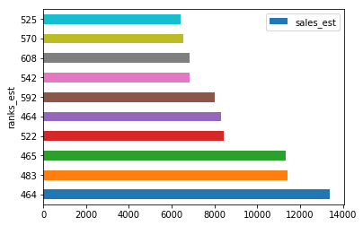

```python
df1.plot(x = 'ranks_est' , y = 'sales_est',kind = 'barh')
```

### Possible Enhancements:

Our script is only taking avg rank as an affecting factor on Sales as of now. If given more time on this, I think a possible improvement can be to feed the hourly rank data in our Model instead of avg rank so that we can bank upon the accuracy of the model. Also, for the sake of time complexity, we considered only two independent variables Date, Ranks but we can definitely consider ratings and other factors while forecasting the Sales values while expediting on the time complexity of the model too.

```
                                    ## Thank you ##
```